# Renewable Energy

## Final Case Study: Renewable Energy Generation

- Ryan Reiser, Luke Hart, Brody Welch, Mason Shandy
- Professor Daniel Jarrett
- Colorado School of Mines
- EBGN 280: Introduction to Business Analytics

## This Analysis takes a deep inspection into the renewable energy industry, and specifically attempts to predict future renewable energy generation in terawatt hours.

The renewable energy industry is one of the most important industries of the future due to the simple fact that everyone needs energy and our planet is rapidly running out of fossil fuels to rely on. As the world becomes more aware of the dangers of fossil fuel pollutants to our environment and as technology innovates more efficient ways to produce clean and renewable energy, how will this industry look into the future?

```python
import warnings
warnings.filterwarnings("ignore", category=Warning)

#Pull in the libraries we need
import numpy as np
import pandas as pd
from pandas import DataFrame
import seaborn as sns
from sklearn.preprocessing import StandardScaler, MinMaxScaler
import matplotlib.pyplot as plt
%matplotlib inline
import statsmodels.api as sm
from sklearn.metrics import mean_squared_error, r2_score
from statsmodels.tsa.stattools import adfuller
from sklearn.model_selection import train_test_split
from sklearn.linear_model import LinearRegression
```

## For this analysis, we decided to try 4 different independent varibles to see how well they could explin our independent variable of Renewable Energy Generation. Those 4 dependent varibles are: Fossil Fuel Price, Fossil Fuel Consumption, Natural Disaster Deaths, and GlobalGDP.

- As climate-related natural disaster deaths increase overtime, people should be more fearful of their futures and interested in supporting renewable energy. Therefore, this data should have a closely positive correlation with renewable energy generation.
- As fossil fuel prices increase, the substitute good of renewable energy should increase in demand. Therefore, this data should have a closely positive correlation with renewable energy generation.
- As fossil fuel consumption increases, there should be less demand for energy and therefore less demand for renewable energy generation. However, it is worth noting that as fossil fuel consumption increases, the world’s finite supply of fossil fuels decreases. Though, it is unlikely we will see this affect the energy industry for another few decades. Therefore, for now, we should see a negative correlation with fossil fuel consumption and renewable energy generation.
- Since most of the world has been built on fossil-fuel powered infrastructure for so long, it takes a lot of investment to build new forms of renewable energy. As World GPD increases, we should see the world have more financial ability to invest in renewable energy. Therefore, this data should have a positive correlation with renewable energy generation.

```python
#Loading data into file
RenewableEnergy = "RenewableEnergyGeneration2.csv"
ffPrice = "FossilFuelPrices.csv"
ffConsumption = "global-fossil-fuel-consumption.csv"
NaturalDisasterDeaths = "number-of-deaths-from-disasters.csv"
GlobalGDP = "global-gdp-over-the-long-run.csv"

#Reading and displaying (some) of the raw data
RenewableEnergy = pd.read_csv(RenewableEnergy)
ffPrice = pd.read_csv(ffPrice)
ffConsumption = pd.read_csv(ffConsumption)
NaturalDisasterDeaths = pd.read_csv(NaturalDisasterDeaths)
GlobalGDP = pd.read_csv(GlobalGDP)
RenewableEnergy.head()
```

|  | Entity | Code | Year | Electricity from wind (TWh) | Electricity from hydro (TWh) | Electricity from solar (TWh) | Other renewables including bioenergy (TWh) | TotalRenewableEnergyGeneration |
| --- | --- | --- | --- | --- | --- | --- | --- | --- |
| 0 | World | OWID_WRL | 1965 | 0.0 | 923.19806 | 0.0 | 17.985231 | 941.183291 |
| 1 | World | OWID_WRL | 1966 | 0.0 | 983.81696 | 0.0 | 19.806007 | 1003.622967 |
| 2 | World | OWID_WRL | 1967 | 0.0 | 1005.74240 | 0.0 | 19.986570 | 1025.728970 |
| 3 | World | OWID_WRL | 1968 | 0.0 | 1059.28870 | 0.0 | 22.120045 | 1081.408745 |
| 4 | World | OWID_WRL | 1969 | 0.0 | 1121.74240 | 0.0 | 23.257965 | 1145.000365 |

## Visualization of Renewable Energy Generation Overtime

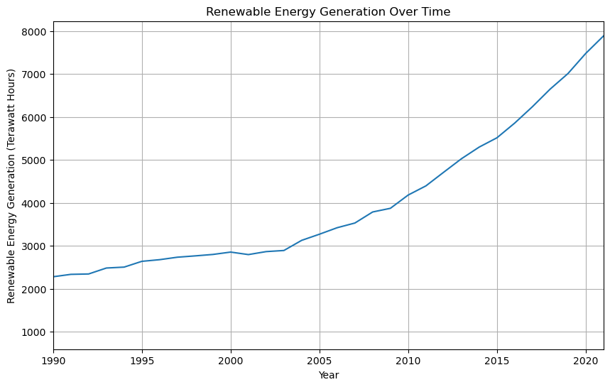

```python
plt.figure(figsize=(10, 6))

# Plot the data
plt.plot(RenewableEnergy['Year'], RenewableEnergy['TotalRenewableEnergyGeneration'])

# Set the title and labels
plt.title('Renewable Energy Generation Over Time')
plt.xlabel('Year')
plt.ylabel('Renewable Energy Generation (Terawatt Hours)')

# Set the x-axis limits to start at 1990 and end at 2021
plt.xlim(1990, 2021)

# Add gridlines
plt.grid(True)

# Show the plot
plt.show()
```

## Fossil Fuel Price (Independent Variable)

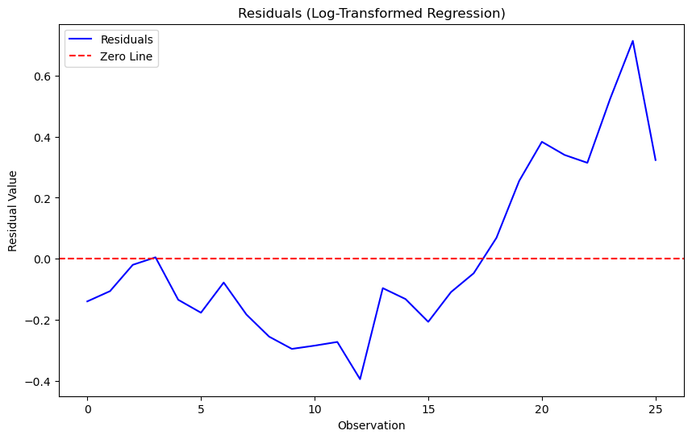

```
                             OLS Regression Results
===============================================================================
Dep. Variable:     log_RenewableEnergy   R-squared:                       0.379
Model:                             OLS   Adj. R-squared:                  0.353
Method:                  Least Squares   F-statistic:                     14.66
Date:                 Tue, 03 Dec 2024   Prob (F-statistic):           0.000812
Time:                         18:12:12   Log-Likelihood:                -3.4497
No. Observations:                   26   AIC:                             10.90
Df Residuals:                       24   BIC:                             13.42
Df Model:                            1
Covariance Type:             nonrobust
=======================================================================================
                          coef    std err          t      P>|t|      [0.025      0.975]
---------------------------------------------------------------------------------------
const                   6.4780      0.484     13.377      0.000       5.479       7.477
Log_FossilFuelPrice     0.4025      0.105      3.828      0.001       0.186       0.619
==============================================================================
Omnibus:                        4.644   Durbin-Watson:                   0.243
Prob(Omnibus):                  0.098   Jarque-Bera (JB):                3.696
Skew:                           0.923   Prob(JB):                        0.158
Kurtosis:                       2.957   Cond. No.                         41.4
==============================================================================

Notes:
[1] Standard Errors assume that the covariance matrix of the errors is correctly specified.
```

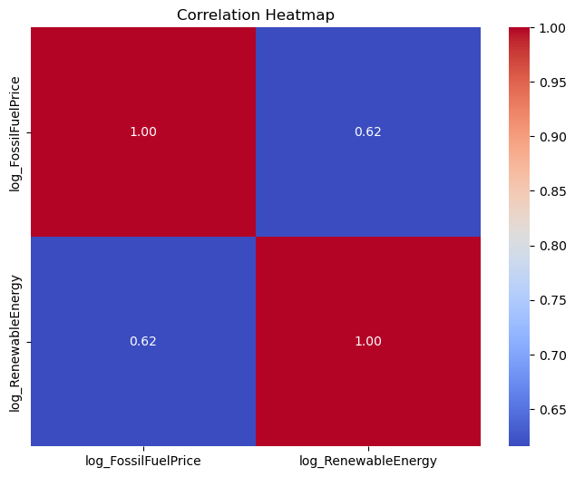

```python
# Clean the datasets
fossil_fuel_prices_cleaned = ffPrice[['Year', 'FossilFuelPriceAverage']].dropna()
renewable_energy_cleaned = RenewableEnergy[['Year', 'TotalRenewableEnergyGeneration']].dropna()

# Rename columns for clarity
renewable_energy_cleaned.rename(columns={'TotalRenewableEnergyGeneration': 'RenewableEnergyGeneration'}, inplace=True)

# Merge the datasets on the 'Year' column
merged_data = pd.merge(fossil_fuel_prices_cleaned, renewable_energy_cleaned, on='Year')

# Take natural logs of the variables
merged_data['log_FossilFuelPrice'] = np.log(merged_data['FossilFuelPriceAverage'])
merged_data['log_RenewableEnergy'] = np.log(merged_data['RenewableEnergyGeneration'])

# Prepare data for regression
X = merged_data[['log_FossilFuelPrice']].values
y = merged_data['log_RenewableEnergy'].values

# Fit a linear regression model
model = LinearRegression()
model.fit(X, y)

# Predict and calculate residuals
merged_data['Predicted'] = model.predict(X)
merged_data['Residuals'] = y - merged_data['Predicted']

# Visualization of residuals
plt.figure(figsize=(10, 6))
plt.plot(merged_data.index, merged_data['Residuals'], label='Residuals', color='blue')
plt.axhline(y=0, color='red', linestyle='--', label='Zero Line')
plt.title('Residuals (Log-Transformed Regression)')
plt.xlabel('Observation')
plt.ylabel('Residual Value')
plt.legend()
plt.show()

# Prepare data for OLS regression
X_ols = merged_data[['log_FossilFuelPrice']]
X_ols = X_ols.rename(columns={'log_FossilFuelPrice': 'Log_FossilFuelPrice'})  # Rename column for clarity
X_ols = sm.add_constant(X_ols)  # Add a constant term for the intercept
y_ols = merged_data['log_RenewableEnergy']

# Fit the OLS model
ols_model = sm.OLS(y_ols, X_ols).fit()

# Print the summary of the OLS regression
print(ols_model.summary())

# Calculate the correlation matrix
correlation_matrix = merged_data[['log_FossilFuelPrice', 'log_RenewableEnergy']].corr()

# Visualize the correlation matrix using a heatmap
plt.figure(figsize=(8, 6))
sns.heatmap(correlation_matrix, annot=True, cmap='coolwarm', fmt='.2f')
plt.title('Correlation Heatmap')
plt.show()
```

We can see that the log of fossil fuel prices is a statistically significant way to predict renewable energy generation with a P < 0.05 and a t > 2.

## Fossil Fuel Consumption (Independent Variable)

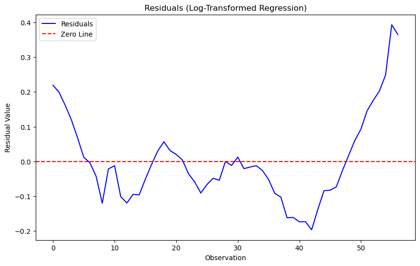

```
                             OLS Regression Results
===============================================================================
Dep. Variable:     log_RenewableEnergy   R-squared:                       0.948
Model:                             OLS   Adj. R-squared:                  0.947
Method:                  Least Squares   F-statistic:                     1007.
Date:                 Tue, 03 Dec 2024   Prob (F-statistic):           4.77e-37
Time:                         18:12:17   Log-Likelihood:                 37.632
No. Observations:                   57   AIC:                            -71.26
Df Residuals:                       55   BIC:                            -67.18
Df Model:                            1
Covariance Type:             nonrobust
===============================================================================================
                                  coef    std err          t      P>|t|      [0.025      0.975]
-----------------------------------------------------------------------------------------------
const                         -10.6698      0.583    -18.294      0.000     -11.839      -9.501
Log_Fossil_Fuel_Consumption     1.6305      0.051     31.739      0.000       1.528       1.733
==============================================================================
Omnibus:                       14.567   Durbin-Watson:                   0.112
Prob(Omnibus):                  0.001   Jarque-Bera (JB):               16.092
Skew:                           1.135   Prob(JB):                     0.000320
Kurtosis:                       4.272   Cond. No.                         396.
==============================================================================

Notes:
[1] Standard Errors assume that the covariance matrix of the errors is correctly specified.
```

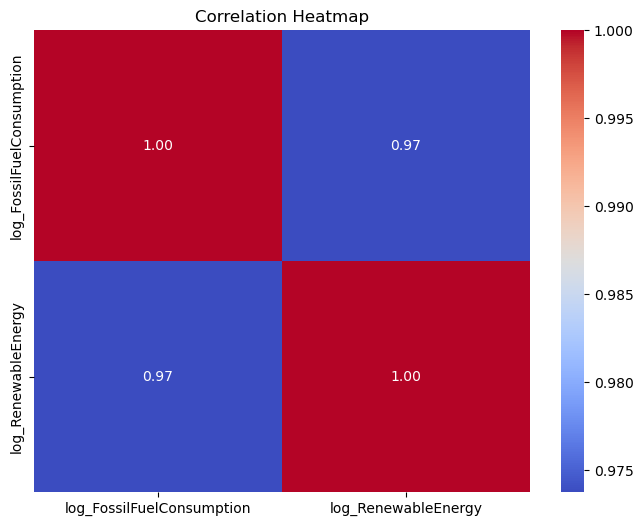

```python
# Clean the datasets
fossil_fuel_prices_cleaned = ffConsumption[['Year', 'Total']].dropna()
renewable_energy_cleaned = RenewableEnergy[['Year', 'TotalRenewableEnergyGeneration']].dropna()

# Rename columns for clarity
renewable_energy_cleaned.rename(columns={'TotalRenewableEnergyGeneration': 'RenewableEnergyGeneration'}, inplace=True)

# Merge the datasets on the 'Year' column
merged_data = pd.merge(fossil_fuel_prices_cleaned, renewable_energy_cleaned, on='Year')

# Take natural logs of the variables
merged_data['log_FossilFuelConsumption'] = np.log(merged_data['Total'])
merged_data['log_RenewableEnergy'] = np.log(merged_data['RenewableEnergyGeneration'])

# Prepare data for regression
X = merged_data[['log_FossilFuelConsumption']].values
y = merged_data['log_RenewableEnergy'].values

# Fit a linear regression model
model = LinearRegression()
model.fit(X, y)

data_df['constant'] = 1

# Predict and calculate residuals
merged_data['Predicted'] = model.predict(X)
merged_data['Residuals'] = y - merged_data['Predicted']

# Visualization of residuals
residuals = merged_data['Residuals']
plt.figure(figsize=(10, 6))
plt.plot(residuals, label='Residuals', color='blue')
plt.axhline(y=0, color='red', linestyle='--', label='Zero Line')
plt.title('Residuals (Log-Transformed Regression)')
plt.xlabel('Observation')
plt.ylabel('Residual Value')
plt.legend()
plt.show()

# Prepare data for OLS regression
X = merged_data[['log_FossilFuelConsumption']]
X = X.rename(columns={'log_FossilFuelConsumption': 'Log_Fossil_Fuel_Consumption'})  # Rename column for clarity
X = sm.add_constant(X)  # Add a constant term for the intercept
y = merged_data['log_RenewableEnergy']

# Fit the OLS model
ols_model = sm.OLS(y, X).fit()

# Print the summary of the OLS regression
print(ols_model.summary())

# Calculate the correlation matrix
correlation_matrix = merged_data[['log_FossilFuelConsumption', 'log_RenewableEnergy']].corr()

# Visualize the correlation matrix using a heatmap
plt.figure(figsize=(8, 6))
sns.heatmap(correlation_matrix, annot=True, cmap='coolwarm', fmt='.2f')
plt.title('Correlation Heatmap')
plt.show()
```

We can see that the log of fossil fuel consumption is a statistically significant way to predict renewable energy generation with a P < 0.05 and a t > 2.

## World GDP (Independent Variable)

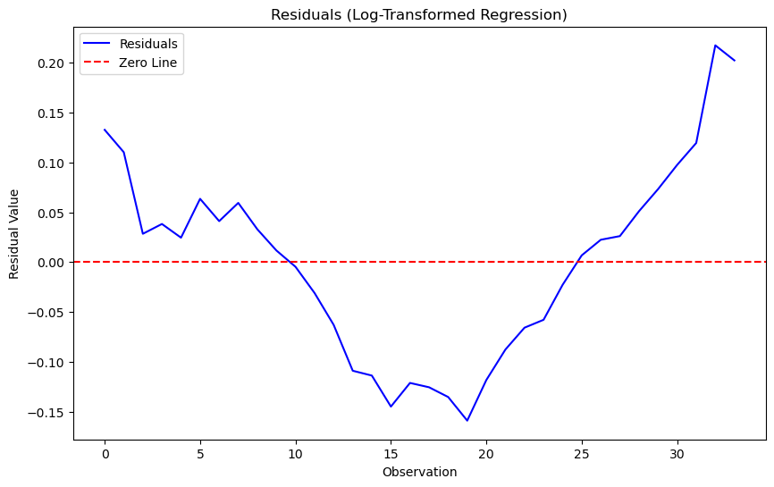

```
                             OLS Regression Results
===============================================================================
Dep. Variable:     log_RenewableEnergy   R-squared:                       0.949
Model:                             OLS   Adj. R-squared:                  0.948
Method:                  Least Squares   F-statistic:                     596.9
Date:                 Tue, 03 Dec 2024   Prob (F-statistic):           2.90e-22
Time:                         15:04:59   Log-Likelihood:                 31.124
No. Observations:                   34   AIC:                            -58.25
Df Residuals:                       32   BIC:                            -55.20
Df Model:                            1
Covariance Type:             nonrobust
==================================================================================
                     coef    std err          t      P>|t|      [0.025      0.975]
----------------------------------------------------------------------------------
const            -27.2543      1.450    -18.798      0.000     -30.208     -24.301
Log_Global_GDP     1.1073      0.045     24.432      0.000       1.015       1.200
==============================================================================
Omnibus:                        0.686   Durbin-Watson:                   0.109
Prob(Omnibus):                  0.710   Jarque-Bera (JB):                0.772
Skew:                           0.225   Prob(JB):                        0.680
Kurtosis:                       2.415   Cond. No.                     2.71e+03
==============================================================================

Notes:
[1] Standard Errors assume that the covariance matrix of the errors is correctly specified.
[2] The condition number is large, 2.71e+03. This might indicate that there are
strong multicollinearity or other numerical problems.
```

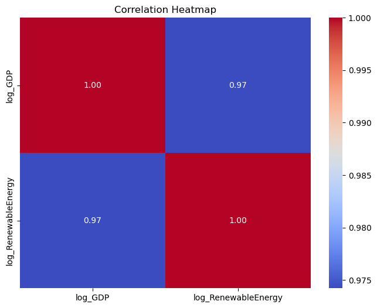

```python
# Clean the datasets
global_gdp_cleaned = GlobalGDP[['Year', 'GDP']].dropna()
renewable_energy_cleaned = RenewableEnergy[['Year', 'TotalRenewableEnergyGeneration']].dropna()

# Rename columns for clarity
renewable_energy_cleaned.rename(columns={'TotalRenewableEnergyGeneration': 'RenewableEnergyGeneration'}, inplace=True)

# Merge the datasets on the 'Year' column
merged_data = pd.merge(global_gdp_cleaned, renewable_energy_cleaned, on='Year')

# Take natural logs of the variables
merged_data['log_GDP'] = np.log(merged_data['GDP'])
merged_data['log_RenewableEnergy'] = np.log(merged_data['RenewableEnergyGeneration'])

# Prepare data for regression
X = merged_data[['log_GDP']].values
y = merged_data['log_RenewableEnergy'].values

# Fit a linear regression model
model = LinearRegression()
model.fit(X, y)

# Predict and calculate residuals
merged_data['Predicted'] = model.predict(X)
merged_data['Residuals'] = y - merged_data['Predicted']

# Visualization of residuals
residuals = merged_data['Residuals']
plt.figure(figsize=(10, 6))
plt.plot(residuals, label='Residuals', color='blue')
plt.axhline(y=0, color='red', linestyle='--', label='Zero Line')
plt.title('Residuals (Log-Transformed Regression)')
plt.xlabel('Observation')
plt.ylabel('Residual Value')
plt.legend()
plt.show()

# Prepare data for OLS regression
X = merged_data[['log_GDP']]
X = X.rename(columns={'log_GDP': 'Log_Global_GDP'})  # Rename column for clarity
X = sm.add_constant(X)  # Add a constant term for the intercept
y = merged_data['log_RenewableEnergy']

# Fit the OLS model
ols_model = sm.OLS(y, X).fit()

# Print the summary of the OLS regression
print(ols_model.summary())

# Calculate the correlation matrix
correlation_matrix = merged_data[['log_GDP', 'log_RenewableEnergy']].corr()

# Visualize the correlation matrix using a heatmap
plt.figure(figsize=(8, 6))
sns.heatmap(correlation_matrix, annot=True, cmap='coolwarm', fmt='.2f')
plt.title('Correlation Heatmap')
plt.show()
```

We can see that the log of Global GDP is a statistically significant way to predict renewable energy generation with a P < 0.05 and a t > 2.

## Natural Disaster Related Deaths (Independent Variable)

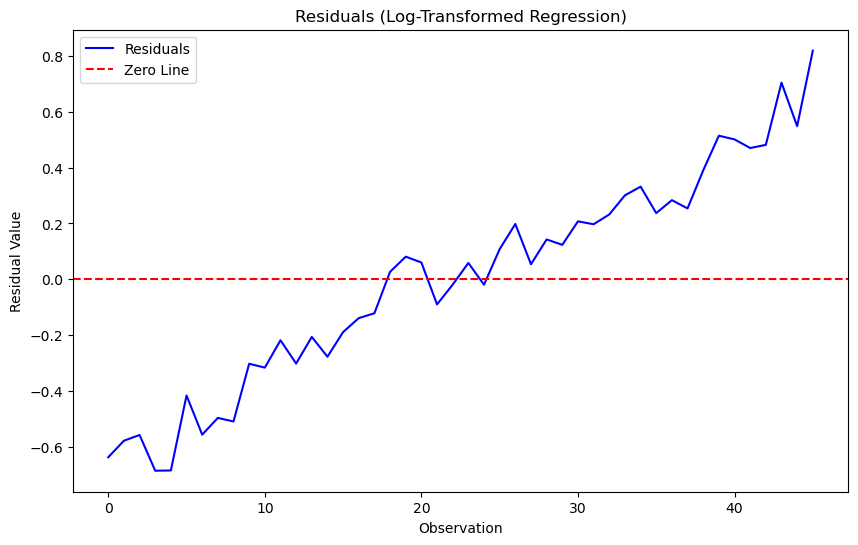

```
                             OLS Regression Results
===============================================================================
Dep. Variable:     log_RenewableEnergy   R-squared:                       0.037
Model:                             OLS   Adj. R-squared:                  0.015
Method:                  Least Squares   F-statistic:                     1.678
Date:                 Tue, 03 Dec 2024   Prob (F-statistic):              0.202
Time:                         15:05:02   Log-Likelihood:                -21.096
No. Observations:                   46   AIC:                             46.19
Df Residuals:                       44   BIC:                             49.85
Df Model:                            1
Covariance Type:             nonrobust
===============================================================================================
                                  coef    std err          t      P>|t|      [0.025      0.975]
-----------------------------------------------------------------------------------------------
const                           8.2507      0.482     17.112      0.000       7.279       9.222
Log_Natural_Disaster_Deaths    -0.0578      0.045     -1.295      0.202      -0.148       0.032
==============================================================================
Omnibus:                        1.766   Durbin-Watson:                   0.078
Prob(Omnibus):                  0.413   Jarque-Bera (JB):                1.179
Skew:                          -0.058   Prob(JB):                        0.555
Kurtosis:                       2.224   Cond. No.                         91.0
==============================================================================

Notes:
[1] Standard Errors assume that the covariance matrix of the errors is correctly specified.
```

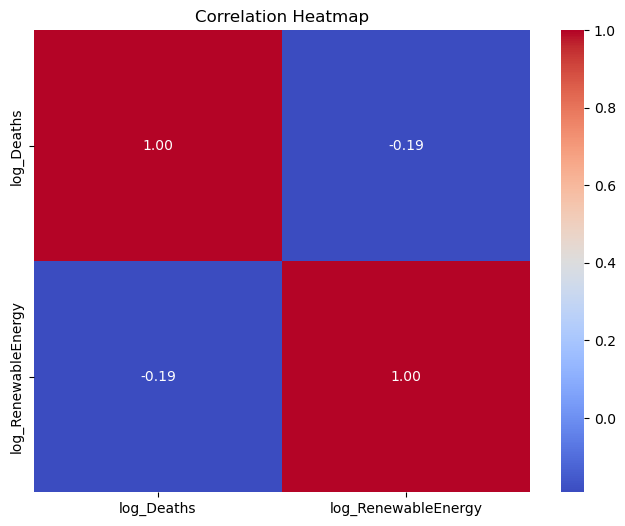

```python
# Clean the datasets
natural_disaster_deaths_cleaned = NaturalDisasterDeaths[['Year', 'Deaths']].dropna()
renewable_energy_cleaned = RenewableEnergy[['Year', 'TotalRenewableEnergyGeneration']].dropna()

# Rename columns for clarity
renewable_energy_cleaned.rename(columns={'TotalRenewableEnergyGeneration': 'RenewableEnergyGeneration'}, inplace=True)

# Merge the datasets on the 'Year' column
merged_data = pd.merge(natural_disaster_deaths_cleaned, renewable_energy_cleaned, on='Year')

# Take natural logs of the variables
merged_data['log_Deaths'] = np.log(merged_data['Deaths'] + 1)  # Adding 1 to avoid log(0)
merged_data['log_RenewableEnergy'] = np.log(merged_data['RenewableEnergyGeneration'])

# Prepare data for regression
X = merged_data[['log_Deaths']].values
y = merged_data['log_RenewableEnergy'].values

# Fit a linear regression model
model = LinearRegression()
model.fit(X, y)

# Predict and calculate residuals
merged_data['Predicted'] = model.predict(X)
merged_data['Residuals'] = y - merged_data['Predicted']

# Visualization of residuals
residuals = merged_data['Residuals']
plt.figure(figsize=(10, 6))
plt.plot(residuals, label='Residuals', color='blue')
plt.axhline(y=0, color='red', linestyle='--', label='Zero Line')
plt.title('Residuals (Log-Transformed Regression)')
plt.xlabel('Observation')
plt.ylabel('Residual Value')
plt.legend()
plt.show()

# Prepare data for OLS regression
X = merged_data[['log_Deaths']]
X = X.rename(columns={'log_Deaths': 'Log_Natural_Disaster_Deaths'})  # Rename column for clarity
X = sm.add_constant(X)  # Add a constant term for the intercept
y = merged_data['log_RenewableEnergy']

# Fit the OLS model
ols_model = sm.OLS(y, X).fit()

# Print the summary of the OLS regression
print(ols_model.summary())

# Calculate the correlation matrix
correlation_matrix = merged_data[['log_Deaths', 'log_RenewableEnergy']].corr()

# Visualize the correlation matrix using a heatmap
plt.figure(figsize=(8, 6))
sns.heatmap(correlation_matrix, annot=True, cmap='coolwarm', fmt='.2f')
plt.title('Correlation Heatmap')
plt.show()
```

We can see that deaths by natural disasters is NOT a statistically significant way to predict renewable energy generation with a P > 0.05 and a t < 2.

## Now we can begin to create a linear regression model to predict Renewable Energy Generation into the future. We will be using our 3 statistically signifigant variables as independent variables.

```
Mean Squared Error: 0.004946167264115579
R-squared: 0.9293851347523677
```

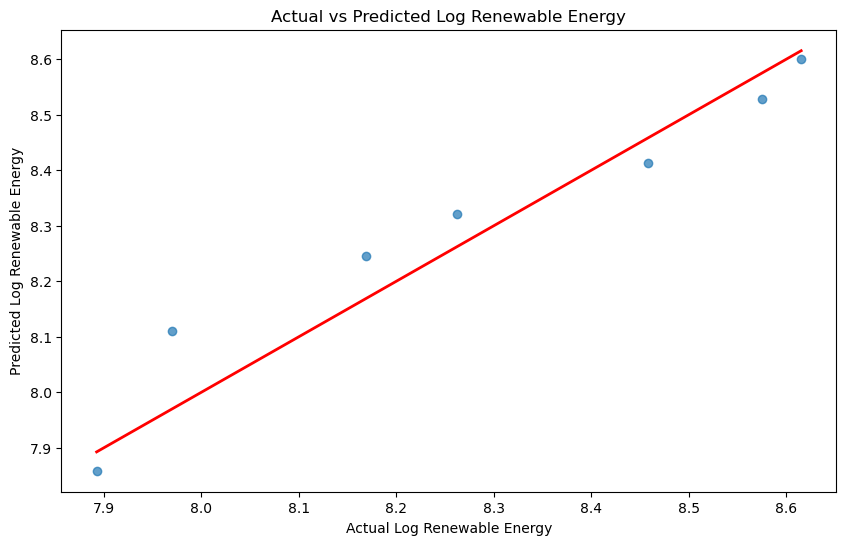

```python
import numpy as np
import matplotlib.pyplot as plt
from sklearn.model_selection import train_test_split
from sklearn.linear_model import LinearRegression
from sklearn.metrics import mean_squared_error, r2_score

# Merge datasets on the 'Year' column
data = (
    renewable_energy_cleaned
    .merge(fossil_fuel_cleaned, on="Year", suffixes=("_renewable", "_fossil"))
    .merge(global_gdp_cleaned, on="Year")
    .merge(fossil_fuel_prices_cleaned, on="Year")
)

# Rename columns for clarity
data.columns = ["Year", "RenewableEnergy", "FossilFuel", "GlobalGDP", "FossilFuelPriceAverage"]

# Drop rows with missing values (if any)
data = data.dropna()

# Apply natural log transformation to relevant columns
data["Log_RenewableEnergy"] = np.log(data["RenewableEnergy"])
data["Log_FossilFuel"] = np.log(data["FossilFuel"])
data["Log_GlobalGDP"] = np.log(data["GlobalGDP"])
data["Log_FossilFuelPriceAverage"] = np.log(data["FossilFuelPriceAverage"])

# Define features (X) and target (y) using log-transformed values
X = data[["Log_FossilFuel", "Log_GlobalGDP", "Log_FossilFuelPriceAverage"]]
y = data["Log_RenewableEnergy"]

# Split data into training and testing sets
X_train, X_test, y_train, y_test = train_test_split(X, y, test_size=0.2, random_state=42)

# Initialize and train the linear regression model
model = LinearRegression()
model.fit(X_train, y_train)

# Make predictions
y_pred = model.predict(X_test)

# Evaluate the model
mse = mean_squared_error(y_test, y_pred)
r2 = r2_score(y_test, y_pred)

print(f"Mean Squared Error: {mse}")
print(f"R-squared: {r2}")

# Plot actual vs predicted values
plt.figure(figsize=(10, 6))
plt.scatter(y_test, y_pred, alpha=0.7)
plt.plot([y_test.min(), y_test.max()], [y_test.min(), y_test.max()], color="red", lw=2)
plt.xlabel("Actual Log Renewable Energy")
plt.ylabel("Predicted Log Renewable Energy")
plt.title("Actual vs Predicted Log Renewable Energy")
plt.show()
```

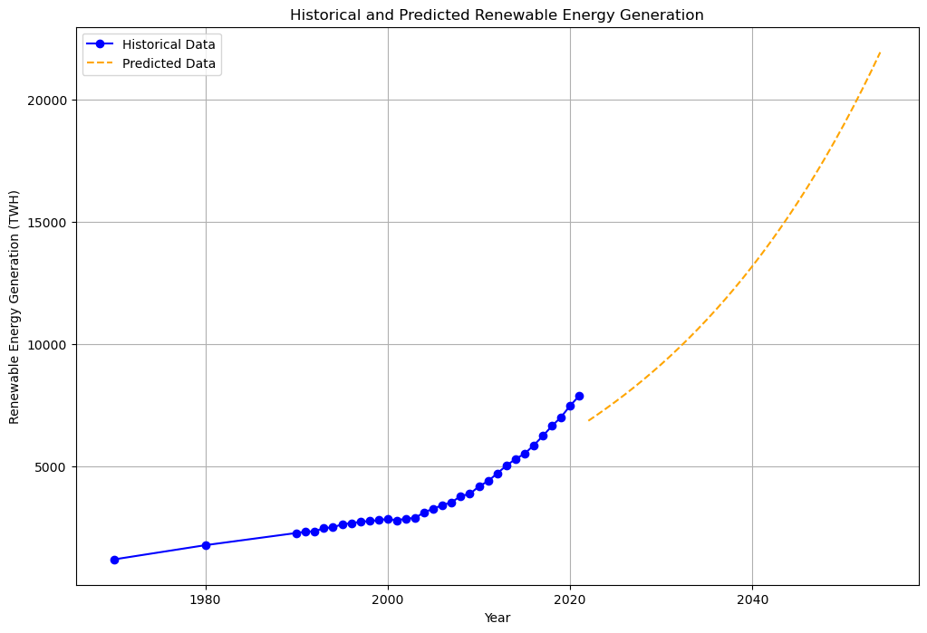

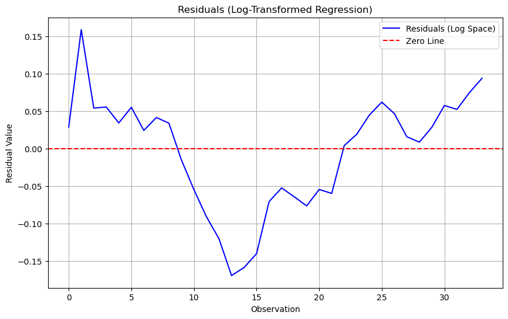

```
                             OLS Regression Results
===============================================================================
Dep. Variable:     Log_RenewableEnergy   R-squared:                       0.969
Model:                             OLS   Adj. R-squared:                  0.967
Method:                  Least Squares   F-statistic:                     489.4
Date:                 Tue, 03 Dec 2024   Prob (F-statistic):           3.56e-24
Time:                         18:26:33   Log-Likelihood:                 39.712
No. Observations:                   34   AIC:                            -73.42
Df Residuals:                       31   BIC:                            -68.85
Df Model:                            2
Covariance Type:             nonrobust
==============================================================================================
                                 coef    std err          t      P>|t|      [0.025      0.975]
----------------------------------------------------------------------------------------------
const                        -44.1626      3.917    -11.276      0.000     -52.151     -36.175
Log_FossilFuelPriceAverage    -1.2352      0.274     -4.514      0.000      -1.793      -0.677
Log_FossilFuel                -1.2352      0.274     -4.514      0.000      -1.793      -0.677
Log_GlobalGDP                  2.5281      0.317      7.980      0.000       1.882       3.174
==============================================================================
Omnibus:                        1.701   Durbin-Watson:                   0.293
Prob(Omnibus):                  0.427   Jarque-Bera (JB):                1.402
Skew:                          -0.486   Prob(JB):                        0.496
Kurtosis:                       2.785   Cond. No.                     2.75e+18
==============================================================================

Notes:
[1] Standard Errors assume that the covariance matrix of the errors is correctly specified.
[2] The smallest eigenvalue is 5.81e-33. This might indicate that there are
strong multicollinearity problems or that the design matrix is singular.
```

```python
# Define the number of years to predict into the future (33 to make the graph end in 2050)
future_years = 33
last_year = data["Year"].max()

# Generate future years
future_years_range = np.arange(last_year + 1, last_year + 1 + future_years)

# Linear Regression for future features
ff_model = LinearRegression()
gdp_model = LinearRegression()
price_model = LinearRegression()

# Train on past data
ff_model.fit(data[["Year"]], np.log(data["FossilFuel"]))  # Log-transformed
gdp_model.fit(data[["Year"]], np.log(data["GlobalGDP"]))  # Log-transformed
price_model.fit(data[["Year"]], np.log(data["FossilFuelPriceAverage"]))  # Log-transformed

# Predict future independent variables
future_fossil_fuel_log = ff_model.predict(future_years_range.reshape(-1, 1))
future_global_gdp_log = gdp_model.predict(future_years_range.reshape(-1, 1))
future_fossil_fuel_price_log = price_model.predict(future_years_range.reshape(-1, 1))

# Exponentiate to get the original scale
future_fossil_fuel = np.exp(future_fossil_fuel_log)
future_global_gdp = np.exp(future_global_gdp_log)
future_fossil_fuel_price = np.exp(future_fossil_fuel_price_log)

# Create a DataFrame for future predictions
future_data = pd.DataFrame({
    "Year": future_years_range,
    "Log_FossilFuel": future_fossil_fuel_log,
    "Log_GlobalGDP": future_global_gdp_log,
    "Log_FossilFuelPriceAverage": future_fossil_fuel_price_log,
})

# Predict future renewable energy values
future_data["Log_RenewableEnergy"] = model.predict(future_data[["Log_FossilFuel", "Log_GlobalGDP", "Log_FossilFuelPriceAverage"]])

# Convert back to original scale for visualization
future_data["RenewableEnergy"] = np.exp(future_data["Log_RenewableEnergy"])

# Combine historical data with future predictions for visualization
historical_data = data[["Year", "RenewableEnergy"]]
combined_data = pd.concat([historical_data, future_data[["Year", "RenewableEnergy"]]])

# Plot historical and predicted renewable energy
plt.figure(figsize=(12, 8))
plt.plot(historical_data["Year"], historical_data["RenewableEnergy"], label="Historical Data", color="blue", marker="o")
plt.plot(future_data["Year"], future_data["RenewableEnergy"], label="Predicted Data", color="orange", linestyle="--")
plt.xlabel("Year")
plt.ylabel("Renewable Energy Generation (TWH)")
plt.title("Historical and Predicted Renewable Energy Generation")
plt.legend()
plt.grid(True)
plt.show()

# Calculate residuals for the entire dataset
data["PredictedLogRenewableEnergy"] = model.predict(X)
data["ResidualsLog"] = y - data["PredictedLogRenewableEnergy"]

# Residual visualization in log-transformed space
plt.figure(figsize=(10, 6))
plt.plot(data.index, data["ResidualsLog"], label="Residuals (Log Space)", color="blue")
plt.axhline(y=0, color="red", linestyle="--", label="Zero Line")
plt.title("Residuals (Log-Transformed Regression)")
plt.xlabel("Observation")
plt.ylabel("Residual Value")
plt.legend()
plt.grid(True)
plt.show()


# Define features (X) and target (y)
X_ols = data[["Log_FossilFuelPriceAverage", "Log_FossilFuel", "Log_GlobalGDP"]]
X_ols = sm.add_constant(X_ols)  # Add constant term
y_ols = data["Log_RenewableEnergy"]

# Fit the OLS model
ols_model = sm.OLS(y_ols, X_ols).fit()

# Print the summary of the OLS regression
print(ols_model.summary())
```

## From this prediction we can see that it is predicted that the renewable energy industry will continue to grow steadily over the coming decades. It is worth noting that this model does not account for every possible factor, as shown from the residuals previously shown, and therefore is not perfectly accurate. Additionally, it is highly likely that unpredictable factors such as political tensions will have major affect on the growth of this industry.